# PEC2 -Distribución normal, Intervalos de Confianza, Regresión y Contrastes de Hipótesis

Nathalia Fernandez Rodrigues

22/12/2020

# 1 **Carga y Preparación del Juego de Datos.**

Se carga el fichero de datos **“car_net.csv”** del directorio de trabajo y se guardan los datos en un objeto llamado **“car”**

```r
setwd("C:/Users/natha/OneDrive/Documents/PEC2")
car<- read.csv("car_net.csv", header=TRUE, sep=",", dec=".", fileEncoding = "UTF-8", stringsAsFactors = TRUE)
```

**Variable “Ancho”**

**ANTES**

```r
car$Ancho
```

```
##   [1]   1.71     1.79   1.79 mts   1.81     1.73     1.93     1.88   1.74 mts
##   [9] 1.74 mts 1.8 mts  1.85 mts   1.85     1.9    1.87 mts   1.89     1.91
##  [17]   1.92   1.79 mts   1.96     1.72     1.76     1.84   1.85 mts   1.88
##  [25]   1.87   1.69 mts   1.59     1.85     1.77     1.76   1.89 mts   1.8
##  [33]   1.89     NA     1.89 mts   1.89     1.76   1.8 mts    1.9      1.92
##  [41]   2.01   2 mts      2        1.82     1.82   1.95 mts   1.7      1.86
##  [49] 1.76 mts   1.85     1.7      1.99   1.78 mts   1.95     2      1.76 mts
##  [57]   2.01     1.7      1.79   1.75 mts   1.79     1.92   1.67 mts   1.7
##  [65]   1.82     1.78   1.82 mts   1.69     1.76   1.84 mts   1.79     1.8
##  [73] 1.8 mts  1.83 mts   1.94     1.82     1.87   1.99 mts 2.03 mts 1.69 mts
##  [81]   1.75     1.74     1.79     1.84   1.78 mts 1.69 mts   1.76     1.77
##  [89] 1.85 mts   1.99   1.78 mts   1.9      1.72     1.8    1.86 mts   1.81
##  [97] 1.71 mts 1.71 mts 1.72 mts   1.86   1.83 mts   1.71     1.76   1.79 mts
## [105]   1.9      1.82     1.79     1.69     1.76     1.87     1.78   1.89 mts
## [113]   1.72     1.83   1.89 mts   1.8    1.95 mts   1.94     1.74     1.79
## [121]   1.89     1.85     1.84   1.85 mts   1.78     1.77     1.77     1.79
## [129] 1.71 mts   1.69     1.69     1.69   1.75 mts   1.75     1.71   1.73 mts
## [137] 1.69 mts   1.78   1.82 mts 1.73 mts   1.69     1.86     1.69   1.69 mts
## [145]   1.94     1.73   1.73 mts   1.74   1.69 mts   1.73     1.72     1.72
## [153]   1.72   1.76 mts   1.76     1.82     1.83
## 55 Levels:   1.59   1.69   1.7   1.71   1.72   1.73   1.74   1.75 ... 2.03 mts
```

**Se elimina ‘mts’ de la variable “Ancho”**

```r
car$Ancho = gsub("mts","", car$Ancho)
```

**DESPUES**

```r
car$Ancho
```

```
##   [1] "  1.71" "  1.79" "1.79 "  "  1.81" "  1.73" "  1.93" "  1.88" "1.74 "
##   [9] "1.74 "  "1.8 "   "1.85 "  "  1.85" "  1.9"  "1.87 "  "  1.89" "  1.91"
##  [17] "  1.92" "1.79 "  "  1.96" "  1.72" "  1.76" "  1.84" "1.85 "  "  1.88"
##  [25] "  1.87" "1.69 "  "  1.59" "  1.85" "  1.77" "  1.76" "1.89 "  "  1.8"
##  [33] "  1.89" "  NA"   "1.89 "  "  1.89" "  1.76" "1.8 "   "  1.9"  "  1.92"
##  [41] "  2.01" "2 "     "  2"    "  1.82" "  1.82" "1.95 "  "  1.7"  "  1.86"
##  [49] "1.76 "  "  1.85" "  1.7"  "  1.99" "1.78 "  "  1.95" "  2"    "1.76 "
##  [57] "  2.01" "  1.7"  "  1.79" "1.75 "  "  1.79" "  1.92" "1.67 "  "  1.7"
##  [65] "  1.82" "  1.78" "1.82 "  "  1.69" "  1.76" "1.84 "  "  1.79" "  1.8"
##  [73] "1.8 "   "1.83 "  "  1.94" "  1.82" "  1.87" "1.99 "  "2.03 "  "1.69 "
##  [81] "  1.75" "  1.74" "  1.79" "  1.84" "1.78 "  "1.69 "  "  1.76" "  1.77"
##  [89] "1.85 "  "  1.99" "1.78 "  "  1.9"  "  1.72" "  1.8"  "1.86 "  "  1.81"
##  [97] "1.71 "  "1.71 "  "1.72 "  "  1.86" "1.83 "  "  1.71" "  1.76" "1.79 "
## [105] "  1.9"  "  1.82" "  1.79" "  1.69" "  1.76" "  1.87" "  1.78" "1.89 "
## [113] "  1.72" "  1.83" "1.89 "  "  1.8"  "1.95 "  "  1.94" "  1.74" "  1.79"
## [121] "  1.89" "  1.85" "  1.84" "1.85 "  "  1.78" "  1.77" "  1.77" "  1.79"
## [129] "1.71 "  "  1.69" "  1.69" "  1.69" "1.75 "  "  1.75" "  1.71" "1.73 "
## [137] "1.69 "  "  1.78" "1.82 "  "1.73 "  "  1.69" "  1.86" "  1.69" "1.69 "
## [145] "  1.94" "  1.73" "1.73 "  "  1.74" "1.69 "  "  1.73" "  1.72" "  1.72"
## [153] "  1.72" "1.76 "  "  1.76" "  1.82" "  1.83"
```

Se eliminan los espacios en blanco de la variable **“Ancho”**

```r
trimws(car$Ancho, which = "both")
```

```
##   [1] "1.71" "1.79" "1.79" "1.81" "1.73" "1.93" "1.88" "1.74" "1.74" "1.8"
##  [11] "1.85" "1.85" "1.9"  "1.87" "1.89" "1.91" "1.92" "1.79" "1.96" "1.72"
##  [21] "1.76" "1.84" "1.85" "1.88" "1.87" "1.69" "1.59" "1.85" "1.77" "1.76"
##  [31] "1.89" "1.8"  "1.89" "NA"   "1.89" "1.89" "1.76" "1.8"  "1.9"  "1.92"
##  [41] "2.01" "2"    "2"    "1.82" "1.82" "1.95" "1.7"  "1.86" "1.76" "1.85"
##  [51] "1.7"  "1.99" "1.78" "1.95" "2"    "1.76" "2.01" "1.7"  "1.79" "1.75"
##  [61] "1.79" "1.92" "1.67" "1.7"  "1.82" "1.78" "1.82" "1.69" "1.76" "1.84"
##  [71] "1.79" "1.8"  "1.8"  "1.83" "1.94" "1.82" "1.87" "1.99" "2.03" "1.69"
##  [81] "1.75" "1.74" "1.79" "1.84" "1.78" "1.69" "1.76" "1.77" "1.85" "1.99"
##  [91] "1.78" "1.9"  "1.72" "1.8"  "1.86" "1.81" "1.71" "1.71" "1.72" "1.86"
## [101] "1.83" "1.71" "1.76" "1.79" "1.9"  "1.82" "1.79" "1.69" "1.76" "1.87"
## [111] "1.78" "1.89" "1.72" "1.83" "1.89" "1.8"  "1.95" "1.94" "1.74" "1.79"
## [121] "1.89" "1.85" "1.84" "1.85" "1.78" "1.77" "1.77" "1.79" "1.71" "1.69"
## [131] "1.69" "1.69" "1.75" "1.75" "1.71" "1.73" "1.69" "1.78" "1.82" "1.73"
## [141] "1.69" "1.86" "1.69" "1.69" "1.94" "1.73" "1.73" "1.74" "1.69" "1.73"
## [151] "1.72" "1.72" "1.72" "1.76" "1.76" "1.82" "1.83"
```

Se comprueba el tipo de dato de la variable **“Ancho”** y se cambia a Decimal

```r
typeof(car$Ancho)
```

```
## [1] "character"
```

Se convierte la variable **“Ancho”** a tipo double con 2 decimales. Se muestra un “Warning: NAs introducidos por coerción”, lo que indica que los datos NAs que ya existian se introduciran igualmente como NAs.

```r
car$Ancho= round(as.numeric(car$Ancho),2)
```

```
## Warning: NAs introducidos por coerción
```

Si comparamos el resultado con el resultado anterior (antes de realizar el cambio de la variable, en la fila [31]) vemos que existe el mismo NA en la variable y no inserta nuevos.

```r
summary(car$Ancho)
```

```
##    Min. 1st Qu.  Median    Mean 3rd Qu.    Max.    NA's
##   1.590   1.740   1.790   1.807   1.863   2.030       1
```

**Se comprueba el tipo de dato de la variable “Grupo” y se cambia a Factor**

```r
car$Grupo= as.factor(car$Grupo)
```

**Listar los cinco fabricantes de vehículos que han vendido más vehículos.**

```r
#Se agrupan por fabricantes
car_mas_vendidos <- aggregate(car[,3], by=list(car$Fabricante),
                              FUN =sum, na.rm=TRUE)
#Ordenar por fabricante con mas ventas
car_mas_vendidos <- car_mas_vendidos[with(car_mas_vendidos,order(-car_mas_vendidos$x)), ]
#Se muestran los primeros 5 fabricantes con mas ventas
car_mas_vendidos[1:5,c(1,2)]
```

```
##      Group.1       x
## 9       Ford 2022635
## 8      Dodge  910149
## 28    Toyota  740205
## 10     Honda  592674
## 6  Chevrolet  554365
```

**Se multiplica las ventas por el precio para saber los ingresos por ventas y se define en millones**

```r
car$Ingreso_ventas = as.integer(as.numeric(car$Ventas) * car$Precio/10^6)
```

```r
#Se agrupan las ventas por fabricantes
car_menos_vendidos <- aggregate(car[,18], by=list(car$Fabricante),
                              FUN =sum, na.rm=TRUE)

#Orden por fabricante con menos ventas
car_menos_vendidos <- car_menos_vendidos[with(car_menos_vendidos,order(car_menos_vendidos$x)),]

#Se muestran los primeros 5 fabricantes con menos ventas
car_menos_vendidos[1:5,c(1,2)]
```

```
##     Group.1    x
## 24  Porsche  601
## 25     Saab  620
## 13   Jaguar  661
## 12 Infiniti  698
## 22 Plymouth 1032
```

**Grafico de sectores según ingresos con los diez fabricantes con mayores ingresos.**

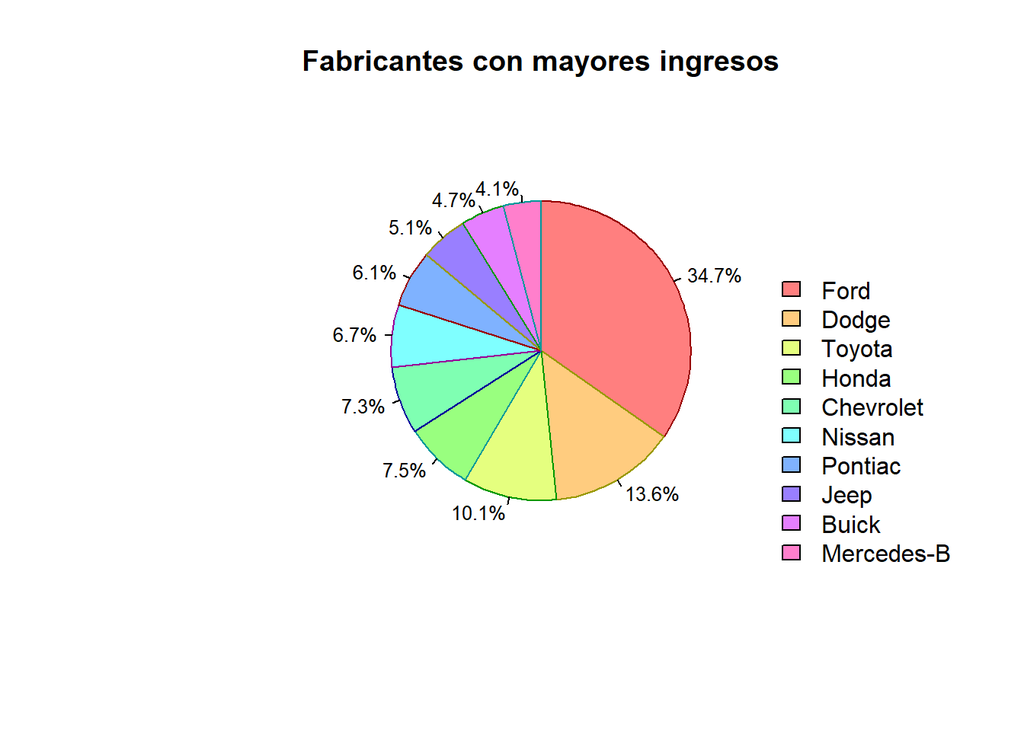

```r
mas_ingresos <- aggregate(car[,18], by=list(car$Fabricante),
                              FUN =sum, na.rm=TRUE)

mas_ingresos <- mas_ingresos[with(mas_ingresos,order(-mas_ingresos$x)),]

mas_ingresos = mas_ingresos[1:10,c(1,2)]

pielabels <- sprintf("%3.1f%s",
                     100*mas_ingresos[,2]/sum(mas_ingresos[,2]), "%")

pieLegend <- sprintf("%s", mas_ingresos[,1])

pie(mas_ingresos[,2],
    labels=pielabels,
    clockwise=TRUE,
    col = rainbow(10, alpha=0.5),
    border = rainbow(6, v=0.6),
    radius=0.7,
    cex=0.8,
    main="Fabricantes con mayores ingresos")
legend("bottomright",legend=pieLegend,bty="n",
       fill=rainbow(10, alpha=0.5))
```